# Maximum Likelihood

Daniel Frederico Lins Leite

19 March 2017

## Gaussian

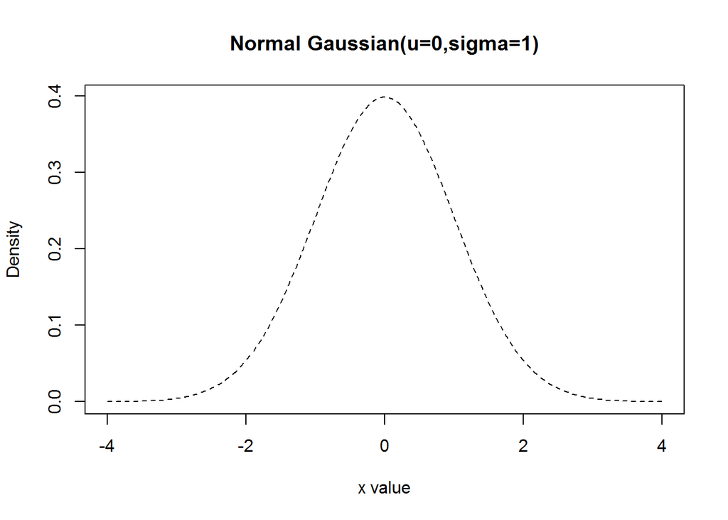

```r
x <- seq(-4, 4, length=100)
hx <- dnorm(x)
plot(x, hx, type="l", lty=2, xlab="x value", ylab="Density", main="Normal Gaussian(u=0,sigma=1)")
```

## Percentage

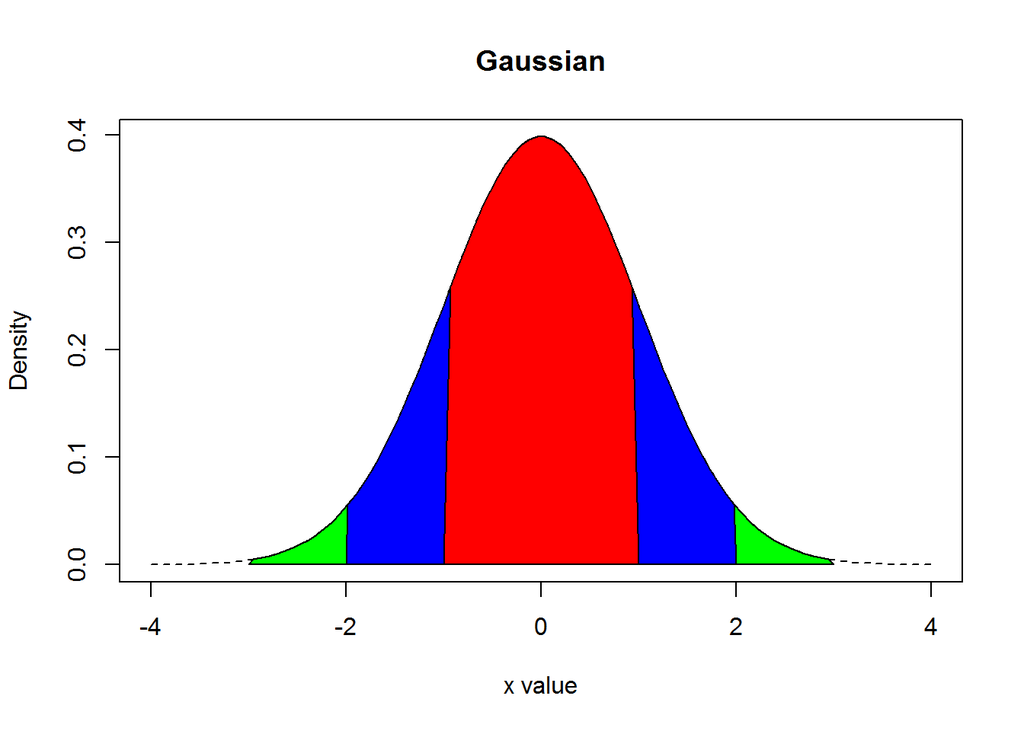

```r
plotGaussian <- function(u, sigma, color = "black"){
  x <- seq(-4, 4, length=100)
  hx <- dnorm(x, mean = u, sd = sigma)
  plot(x, hx, type="l", lty=2, xlab="x value", ylab="Density", main="Gaussian", col = color)
}
plotArea <- function(u, sigma, sigmaSize, color){
  x <- seq(-4, 4, length=100)
  hx <- dnorm(x, mean = u, sd = sigma)
  l <- -(sigma*sigmaSize)
  r <- (sigma*sigmaSize)
  i <- x >= l & x <= r
  polygon(c(l,x[i],r), c(0,hx[i],0), col=color)
}

plot.new()
plotGaussian(0,1)
plotArea(0,1,3,"green")
plotArea(0,1,2,"blue")
plotArea(0,1,1,"red")
```

## Density Simulation

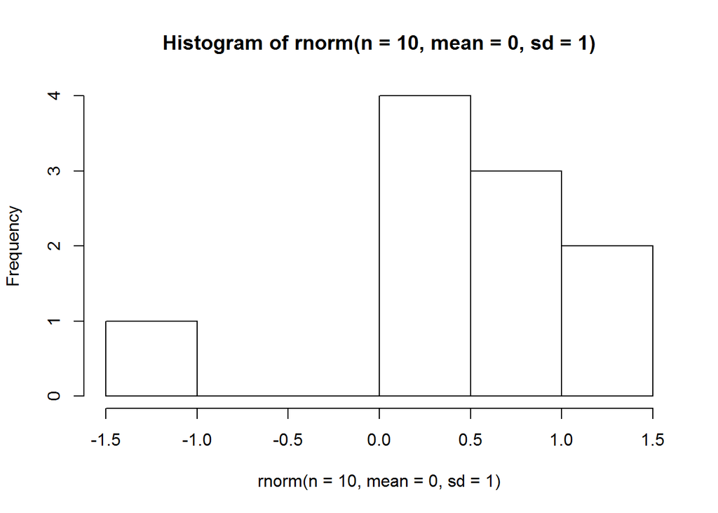

```r
hist(rnorm(n = 10, mean = 0, sd = 1))
```

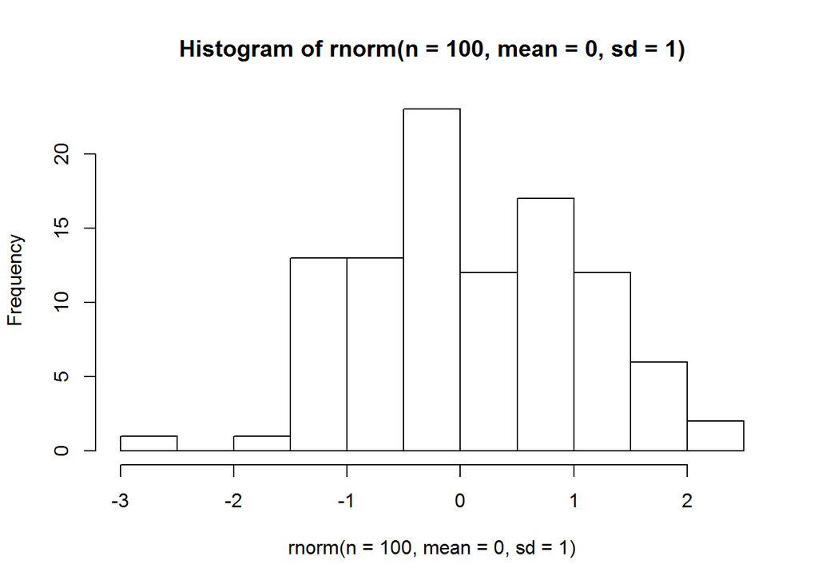

```r
hist(rnorm(n = 100, mean = 0, sd = 1))
```

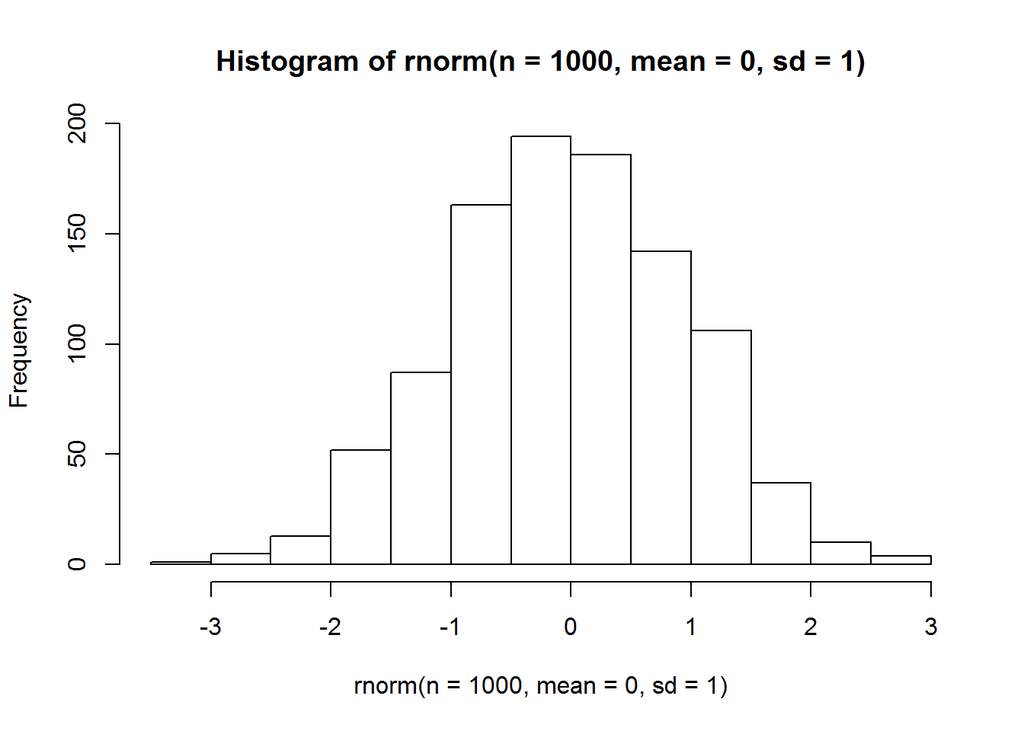

```r
hist(rnorm(n = 1000, mean = 0, sd = 1))
```

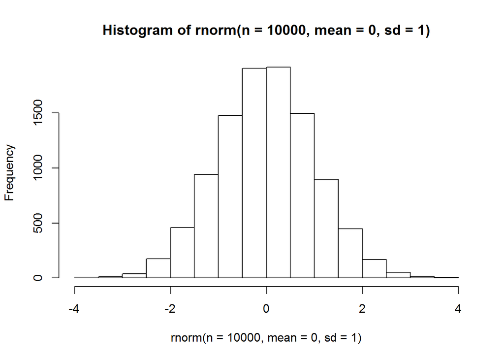

```r
hist(rnorm(n = 10000, mean = 0, sd = 1))
```

## Likelihood

Suppose we have an observation and two possible distributions that can be considered as the source distributions of this observations. We want to choose the best option: in this case the most probable source distribution.

Options:  
Gaussian #1  
u = -2  
sd = 1

Gaussian #2  
u = 2  
sd = 1

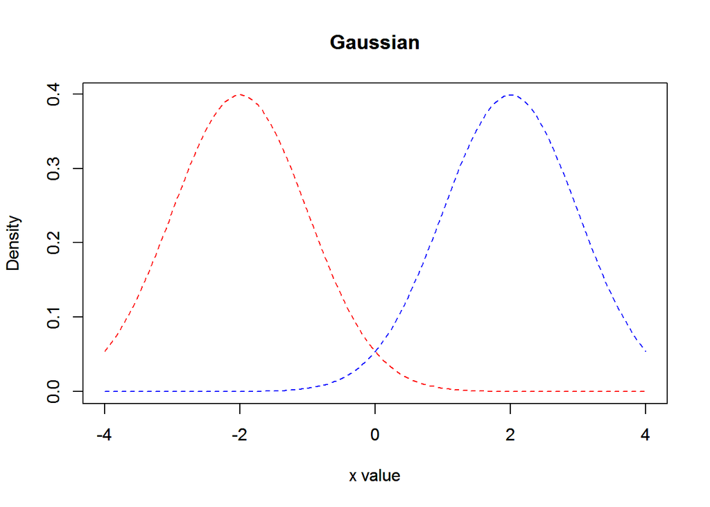

```r
plotGaussian(-2,1,"red")
par(new=TRUE)
plotGaussian(2,1, "blue")
```

Observations  
A = -0.25  
B = -1  
C = 0.45

To choose the best distribution we will choose the distribution whose density is bigger in that particular point. For example, for observation A:

Probability of observing A from Gaussian #1 (u-2,sd=1) = 0.0862773  
Probability of observing A from Gaussian #2 (u=2,sd=1) = 0.0317397

In this case the best option is Gaussian #1. It is more likely/probable that the observation #A comes from Gaussian #1 than Gaussian #2.

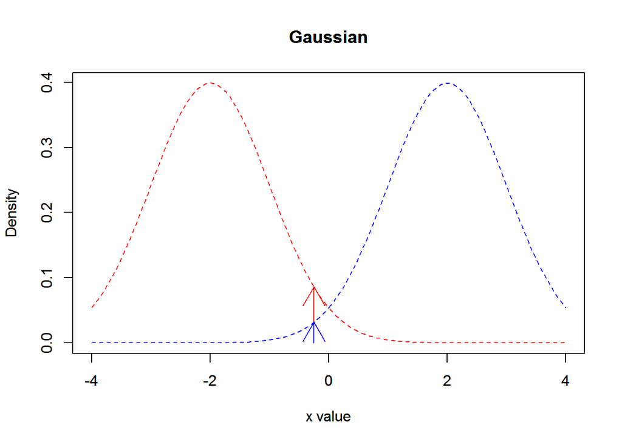

```r
plotGaussian(-2,1,"red")
arrows(-0.25,0,-0.25,dnorm(-0.25,-2,1), col = "red")
par(new=TRUE)
plotGaussian(2,1, "blue")
arrows(-0.25,0,-0.25,dnorm(-0.25,2,1), col = "blue")
```

We can use the same calculations to the others observations.

Probability of observing B from Gaussian #1 (u-2,sd=1) = 0.2419707  
Probability of observing B from Gaussian #2 (u=2,sd=1) = 0.0044318  
Probability of observing C from Gaussian #1 (u-2,sd=1) = 0.0198374  
Probability of observing C from Gaussian #2 (u=2,sd=1) = 0.120009

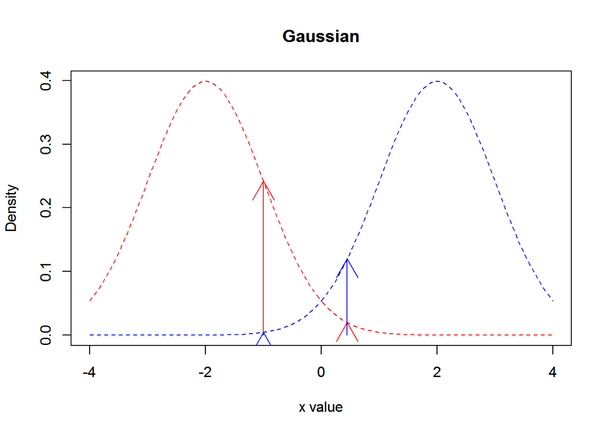

```r
plotGaussian(-2,1,"red")
arrows(-1,0,-1,dnorm(-1,-2,1), col = "red")
arrows(0.45,0,0.45,dnorm(0.45,-2,1), col = "red")
par(new=TRUE)
plotGaussian(2,1, "blue")
arrows(-1,0,-1,dnorm(-1,2,1), col = "blue")
arrows(0.45,0,0.45,dnorm(0.45,2,1), col = "blue")
```

So we can sau that:  
The likelihood of u = -2 and sd = 1 for a observation -1 is 0.2419707 because the probability of seeing a value -1 from a Gaussian with u = -2 and sd = 1 is 0.2419707.  
In others words:  
The likelihood of theta, the gaussian parameters, given x is 0.2419707 because the probability of x given theta is 0.2419707.  
Or:

[figure not shown]